# EDA_of_App_Store

ShikuiWang

2/5/2019

Data is downloaded from Kaggle(https://www.kaggle.com/ramamet4/app-store-apple-data-set-10k-apps) Explore the data to get some useful information

The ever-changing mobile landscape is a challenging space to navigate. . The percentage of mobile over desktop is only increasing. Android holds about 53.2% of the smartphone market, while iOS is 43%. To get more people to download your app, you need to make sure they can easily find your app. Mobile app analytics is a great way to understand the existing strategy to drive growth and retention of future user.

With million of apps around nowadays, the following data set has become very key to getting top trending apps in iOS app store. This data set contains more than 7000 Apple iOS mobile application details. The data was extracted from the iTunes Search API at the Apple Inc website. R and linux web scraping tools were used for this study.

Data collection date (from API); July 2017

#### appleStore.csv

“id” : App ID

“track_name”: App Name

“size_bytes”: Size (in Bytes)

“currency”: Currency Type

“price”: Price amount

“rating_count_tot”: User Rating counts (for all version)

“rating_count_ver”: User Rating counts (for current version)

“user_rating” : Average User Rating value (for all version)

“user_rating_ver”: Average User Rating value (for current version)

“ver” : Latest version code

“cont_rating”: Content Rating

“prime_genre”: Primary Genre

“sup_devices.num”: Number of supporting devices

“ipadSc_urls.num”: Number of screenshots showed for display

“lang.num”: Number of supported languages

“vpp_lic”: Vpp Device Based Licensing Enabled

#### appleStore_description.csv

id : App ID track_name: Application name size_bytes: Memory size (in Bytes) app_desc: Application description

## 1. Load the data

```r
library(dplyr)
```

```r
library(ggplot2)
library(treemap)
library(scales)
library(stringr)

app <- read.csv('/Users/wangshikui/Desktop/SPRING/Python Learning Notebook/R/app-store-apple-data-set-10k-apps/AppleStore.csv')

description <- read.csv('/Users/wangshikui/Desktop/SPRING/Python Learning Notebook/R/app-store-apple-data-set-10k-apps/appleStore_description.csv')


# Join two datasets
full <- app %>% left_join(description, by = 'id')
head(full,1)
```

```
##   X        id    track_name.x size_bytes.x currency price rating_count_tot
## 1 1 281656475 PAC-MAN Premium    100788224      USD  3.99            21292
##   rating_count_ver user_rating user_rating_ver   ver cont_rating
## 1               26           4             4.5 6.3.5          4+
##   prime_genre sup_devices.num ipadSc_urls.num lang.num vpp_lic
## 1       Games              38               5       10       1
##      track_name.y size_bytes.y
## 1 PAC-MAN Premium    100788224
##                                                                                                                                                                                                                                                                                                          …
## 1 SAVE 20%, now only $3.99 for a limited time!\n\nOne of the most popular video games in arcade history!\n2015 World Video Game Hall of Fame Inductee\n\nWho can forget the countless hours and quarters spent outrunning pesky ghosts and chompin\342\200\231 on dots? Now you can have the same arcade …
```

```r
dim(full)
```

```
## [1] 7197   20
```

## 2. Data Cleaning

```r
# 1. Is there missing value?
apply(full, 2,is.null)
```

```
##                X               id     track_name.x     size_bytes.x
##            FALSE            FALSE            FALSE            FALSE
##         currency            price rating_count_tot rating_count_ver
##            FALSE            FALSE            FALSE            FALSE
##      user_rating  user_rating_ver              ver      cont_rating
##            FALSE            FALSE            FALSE            FALSE
##      prime_genre  sup_devices.num  ipadSc_urls.num         lang.num
##            FALSE            FALSE            FALSE            FALSE
##          vpp_lic     track_name.y     size_bytes.y         app_desc
##            FALSE            FALSE            FALSE            FALSE
```

```r
# 2. is ther dupliate value?
sum(duplicated(full))
```

```
## [1] 0
```

```r
# 3. After joining, there are two columns representing same things, delete either one of those two
full <- full %>% select(-c(size_bytes.x,track_name.x))
full <- full %>% rename(size = size_bytes.y, name = track_name.y)
```

## 3. Data Manipulation

```r
# 1. Convert byte to Megabyte
full <- full %>% mutate(size = size/1048576)
full$size <- round(full$size, 2)

# 2. Create a new column 'Paid' which indicates whether an app is free or not for convinience of further exploration
full <- full %>% mutate(paid = if_else(price != 0, 'Yes', 'No'))
str(full)
```

```
## 'data.frame':    7197 obs. of  19 variables:
##  $ X               : int  1 2 3 4 5 6 7 8 9 10 ...
##  $ id              : int  281656475 281796108 281940292 282614216 282935706 283619399 283646709 284035177 284666222 284736660 ...
##  $ currency        : Factor w/ 1 level "USD": 1 1 1 1 1 1 1 1 1 1 ...
##  $ price           : num  3.99 0 0 0 0 0.99 0 0 9.99 3.99 ...
##  $ rating_count_tot: int  21292 161065 188583 262241 985920 8253 119487 1126879 1117 7885 ...
##  $ rating_count_ver: int  26 26 2822 649 5320 5516 879 3594 4 40 ...
##  $ user_rating     : num  4 4 3.5 4 4.5 4 4 4 4.5 4 ...
##  $ user_rating_ver : num  4.5 3.5 4.5 4.5 5 4 4.5 4.5 5 4 ...
##  $ ver             : Factor w/ 1590 levels "0.0.15","0.13",..: 1380 1515 1211 1237 1473 455 1360 1523 1009 1068 ...
##  $ cont_rating     : Factor w/ 4 levels "12+","17+","4+",..: 3 3 3 1 3 3 3 1 3 3 ...
##  $ prime_genre     : Factor w/ 23 levels "Book","Business",..: 8 16 23 18 17 8 6 12 22 8 ...
##  $ sup_devices.num : int  38 37 37 37 37 47 37 37 37 38 ...
##  $ ipadSc_urls.num : int  5 5 5 5 5 5 0 4 5 0 ...
##  $ lang.num        : int  10 23 3 9 45 1 19 1 1 10 ...
##  $ vpp_lic         : int  1 1 1 1 1 1 1 1 1 1 ...
##  $ name            : Factor w/ 7195 levels "! OH Fantastic Free Kick + Kick Wall Challenge",..: 3677 1665 5871 6133 528 4529 3785 3741 3689 3311 ...
##  $ size            : num  96.1 151.2 95.9 122.6 88.5 ...
##  $ app_desc        : Factor w/ 7147 levels "! Now on X'mas special sales (~2017 Jan. 3rd) ! \n\nIT WAS JUST A COMMON DAY.\nTHE WORLD IS OVER.\nONE BIRD SUR"| __truncated__,..: 4185 3142 1892 4913 3595 6374 1751 2280 3680 3546 ...
##  $ paid            : chr  "Yes" "No" "No" "No" ...
```

```r
# 3. Remove unnecessary columns
full <- full %>% select(-X)
```

## 4. Exploratory Data Analysis

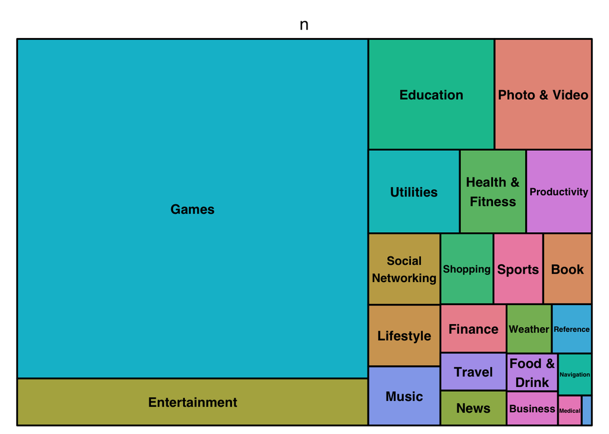

```r
# 1. Preliminary Analysis
# 1.1 Frequency of genres
full %>% group_by(prime_genre) %>% count() %>% treemap(index = 'prime_genre',vSize = 'n', type = 'index')
```

```r
# Games accouts for significant proportion of all apps, so do Entertainment, Education and Photo & Video
```

```r
## 1.2 What apps are most expensive
full %>% arrange(desc(price)) %>% select(name,prime_genre, price) %>% top_n(5)
```

```
##                                               name  prime_genre  price
## 1                              LAMP Words For Life    Education 299.99
## 2                   Proloquo2Go - Symbol-based AAC    Education 249.99
## 3                                      KNFB Reader Productivity  99.99
## 4                                   NAVIGON Europe   Navigation  74.99
## 5                         Articulation Station Pro    Education  59.99
## 6                     Articulation Test Center Pro    Education  59.99
## 7 FineScanner Pro - PDF Document Scanner App + OCR     Business  59.99
```

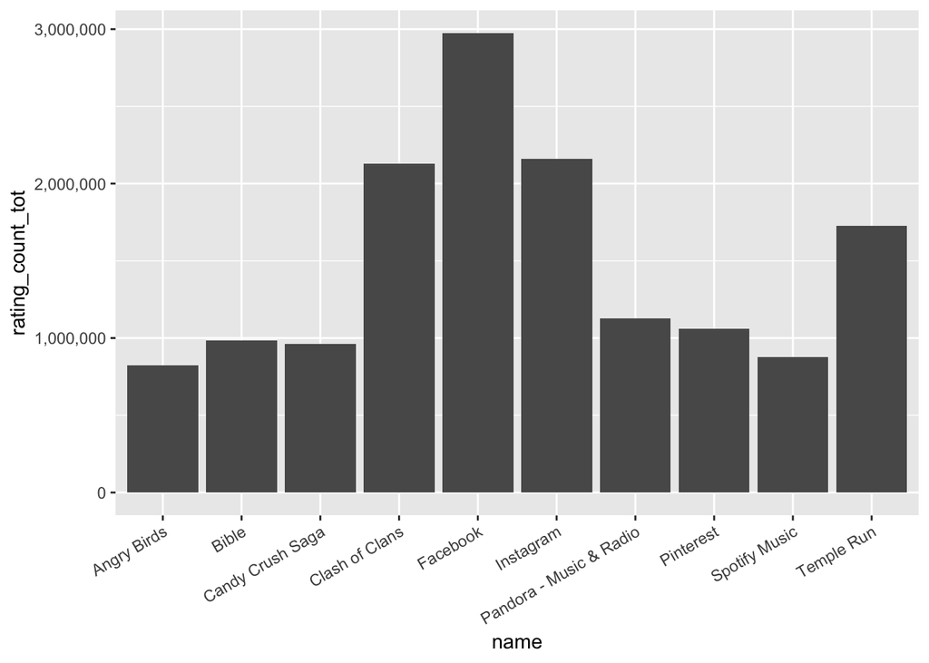

```r
# 1.3 What are most popular apps in general?
full %>% select(name,rating_count_tot) %>% arrange(desc(rating_count_tot)) %>%
  top_n(10) %>% ggplot(aes(x = name, y = rating_count_tot)) + geom_bar(stat = 'identity') +
  theme(axis.text.x = element_text(angle = 30, hjust = 1)) +
  scale_y_continuous(label = comma)
```

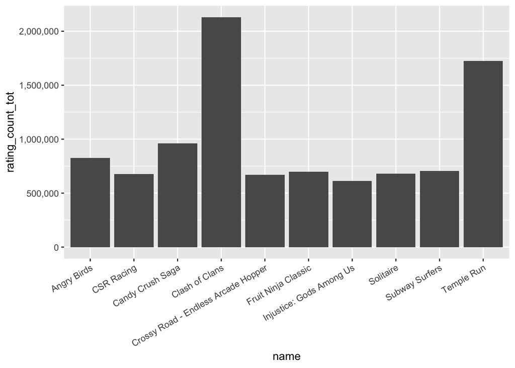

```r
# 1.4 What are most popular games?
full %>% filter(prime_genre == 'Games') %>% select(name,rating_count_tot) %>% arrange(desc(rating_count_tot)) %>%
  top_n(10) %>% ggplot(aes(x = name, y = rating_count_tot)) + geom_bar(stat = 'identity') +
  theme(axis.text.x = element_text(angle = 30, hjust = 1)) +
  scale_y_continuous(label = comma)
```

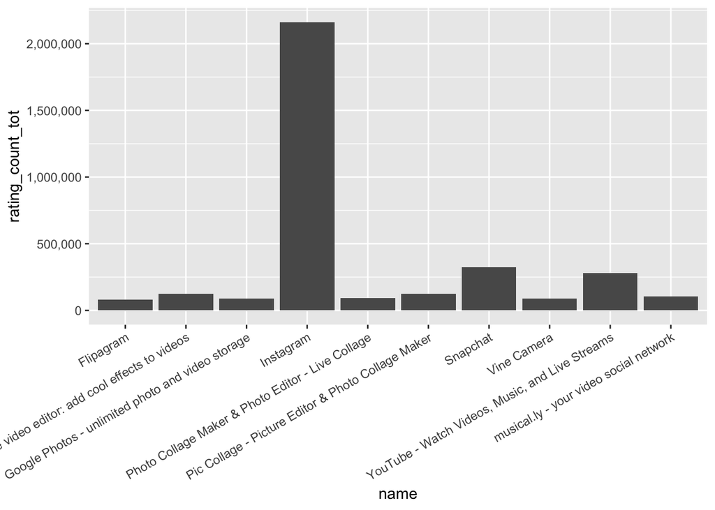

```r
## 1.5 What are most popular Photo & Video apps? (Because I love taking photos:))
full %>% filter(prime_genre == 'Photo & Video') %>% select(name,rating_count_tot) %>% arrange(desc(rating_count_tot)) %>%
  top_n(10) %>% ggplot(aes(x = name, y = rating_count_tot)) + geom_bar(stat = 'identity') +
  theme(axis.text.x = element_text(angle = 30, hjust = 1)) +
  scale_y_continuous(label = comma)
```

## 1.6 Does size has relationship with price?

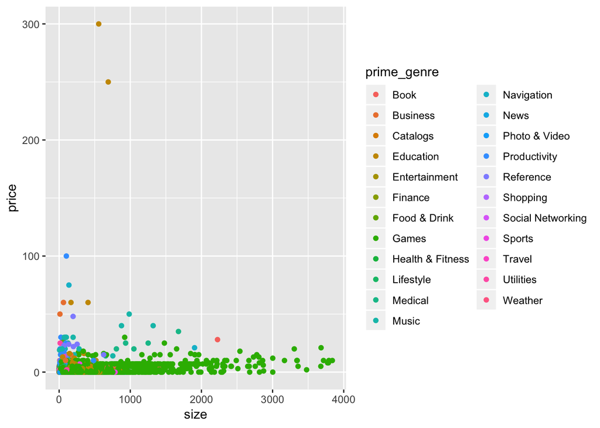

```r
full %>% ggplot(aes(x = size, y = price, color = prime_genre)) + geom_point()
```

Seems like there is no relationship between price and size, and game apps are all generally less than 50 dollars

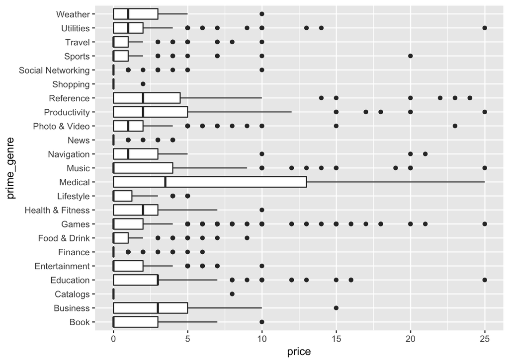

```r
# 2. More Analysis
# 2.1 What is distribution of price by genres
full %>%  mutate(Free = if_else(price != 0, 'Non-Free', 'Free')) %>% select(prime_genre, price, Free) %>%
  ggplot(aes(x = prime_genre, y = price)) + geom_boxplot() + ylim(c(0,25)) + coord_flip()
```

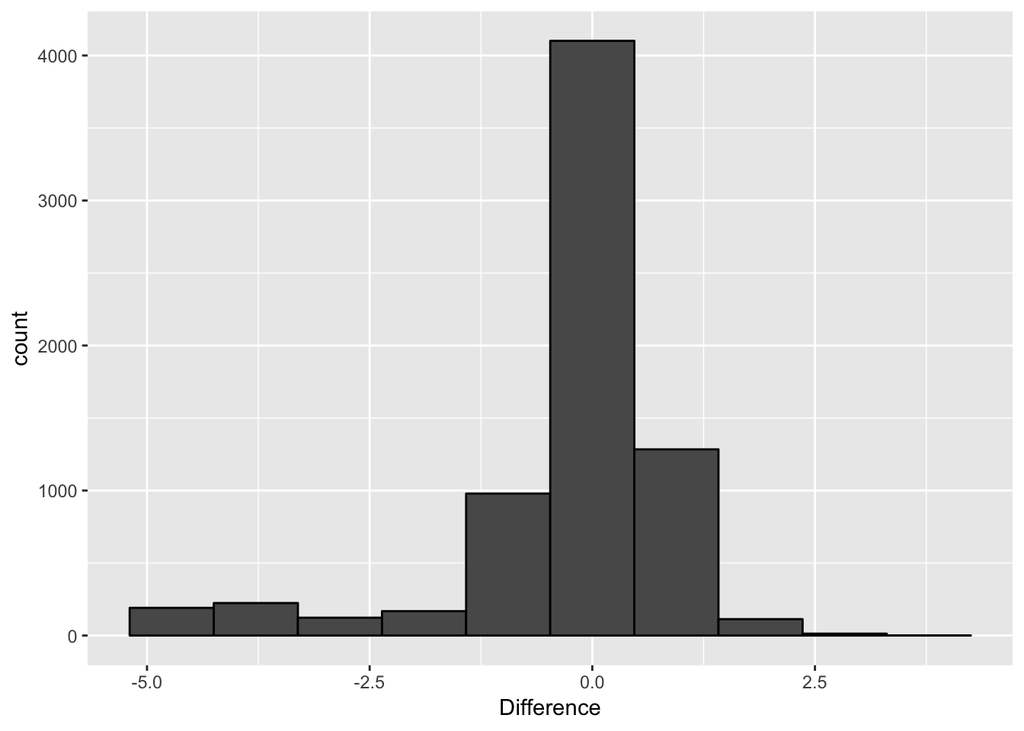

```r
# 2.2 Overall, If current versions of apps are better versions? (based on difference between average rating and current version rating)
full %>% select(user_rating, user_rating_ver) %>% mutate(diff = user_rating_ver-user_rating) %>% ggplot(aes(x = diff))+ xlab(label = 'Difference') +
  geom_histogram(colour = 'black', bins = 10)
```